# EasyVisa Project

## Context:

Business communities in the United States are facing high demand for human resources, but one of the constant challenges is identifying and attracting the right talent, which is perhaps the most important element in remaining competitive. Companies in the United States look for hard-working, talented, and qualified individuals both locally as well as abroad.

The Immigration and Nationality Act (INA) of the US permits foreign workers to come to the United States to work on either a temporary or permanent basis. The act also protects US workers against adverse impacts on their wages or working conditions by ensuring US employers' compliance with statutory requirements when they hire foreign workers to fill workforce shortages. The immigration programs are administered by the Office of Foreign Labor Certification (OFLC).

OFLC processes job certification applications for employers seeking to bring foreign workers into the United States and grants certifications in those cases where employers can demonstrate that there are not sufficient US workers available to perform the work at wages that meet or exceed the wage paid for the occupation in the area of intended employment.

## Objective:

In FY 2016, the OFLC processed 775,979 employer applications for 1,699,957 positions for temporary and permanent labor certifications. This was a nine percent increase in the overall number of processed applications from the previous year. The process of reviewing every case is becoming a tedious task as the number of applicants is increasing every year.

The increasing number of applicants every year calls for a Machine Learning based solution that can help in shortlisting the candidates having higher chances of VISA approval. OFLC has hired your firm EasyVisa for data-driven solutions. You as a data scientist have to analyze the data provided and, with the help of a classification model:

- Facilitate the process of visa approvals.
- Recommend a suitable profile for the applicants for whom the visa should be certified or denied based on the drivers that significantly influence the case status.

## Data Description

The data contains the different attributes of the employee and the employer. The detailed data dictionary is given below.

- case_id: ID of each visa application
- continent: Information of continent the employee
- education_of_employee: Information of education of the employee
- has_job_experience: Does the employee has any job experience? Y= Yes; N = No
- requires_job_training: Does the employee require any job training? Y = Yes; N = No
- no_of_employees: Number of employees in the employer's company
- yr_of_estab: Year in which the employer's company was established
- region_of_employment: Information of foreign worker's intended region of employment in the US.
- prevailing_wage: Average wage paid to similarly employed workers in a specific occupation in the area of intended employment. The purpose of the prevailing wage is to ensure that the foreign worker is not underpaid compared to other workers offering the same or similar service in the same area of employment.
- unit_of_wage: Unit of prevailing wage. Values include Hourly, Weekly, Monthly, and Yearly.
- full_time_position: Is the position of work full-time? Y = Full Time Position; N = Part Time Position
- case_status: Flag indicating if the Visa was certified or denied

## Importing necessary libraries and data

```python
# Installing the libraries with the specified version.
!pip install numpy==1.25.2 pandas==1.5.3 scikit-learn==1.2.2 matplotlib==3.7.1 seaborn==0.13.1 xgboost==2.0.3
```

```python
# import libraries for data manipulation
import numpy as np
import pandas as pd

# import libraries for data visualization
import matplotlib.pyplot as plt
import seaborn as sns

# import library for probability distribution and statistic data
import scipy.stats as stats

#libraries for model building and tuning
from sklearn import tree
from sklearn.tree import DecisionTreeClassifier
from sklearn.ensemble import (BaggingClassifier,RandomForestClassifier,
                              GradientBoostingClassifier, AdaBoostClassifier, StackingClassifier)
from xgboost import XGBClassifier
from sklearn.model_selection import train_test_split
from sklearn.model_selection import GridSearchCV, RandomizedSearchCV

#libraries for metrics and statistics
from sklearn import metrics
import scipy.stats as stats
from sklearn.metrics import confusion_matrix, classification_report
from sklearn.metrics import accuracy_score,precision_score,recall_score,f1_score, roc_auc_score

import warnings
warnings.filterwarnings('ignore')
```

**Note**: *After running the above cell, kindly restart the notebook kernel and run all cells sequentially from the start again.*

```python
# Mounted at /content/drive for Google Colab to get required data from drive
from google.colab import drive
drive.mount("/content/drive", force_remount=True)
```

```python
# read the data from dataset using panda
dataframe = pd.read_csv("/content/drive/MyDrive/EasyVisa.csv")
```

## Data Overview

- Observations
- Sanity checks

```python
# Create a copy of the DataFrame
df = dataframe.copy()
```

```python
# After successfull read the data, we can use head() function to view the first 5 rows
df.head()
```

|  | case_id | continent | education_of_employee | has_job_experience | requires_job_training | no_of_employees | yr_of_estab | region_of_employment | prevailing_wage | unit_of_wage | full_time_position | case_status |
| --- | --- | --- | --- | --- | --- | --- | --- | --- | --- | --- | --- | --- |
| 0 | EZYV01 | Asia | High School | N | N | 14513 | 2007 | West | 592.2029 | Hour | Y | Denied |
| 1 | EZYV02 | Asia | Master's | Y | N | 2412 | 2002 | Northeast | 83425.6500 | Year | Y | Certified |
| 2 | EZYV03 | Asia | Bachelor's | N | Y | 44444 | 2008 | West | 122996.8600 | Year | Y | Denied |
| 3 | EZYV04 | Asia | Bachelor's | N | N | 98 | 1897 | West | 83434.0300 | Year | Y | Denied |
| 4 | EZYV05 | Africa | Master's | Y | N | 1082 | 2005 | South | 149907.3900 | Year | Y | Certified |

```python
# print last five rows
df.tail()
```

|  | case_id | continent | education_of_employee | has_job_experience | requires_job_training | no_of_employees | yr_of_estab | region_of_employment | prevailing_wage | unit_of_wage | full_time_position | case_status |
| --- | --- | --- | --- | --- | --- | --- | --- | --- | --- | --- | --- | --- |
| 25475 | EZYV25476 | Asia | Bachelor's | Y | Y | 2601 | 2008 | South | 77092.57 | Year | Y | Certified |
| 25476 | EZYV25477 | Asia | High School | Y | N | 3274 | 2006 | Northeast | 279174.79 | Year | Y | Certified |
| 25477 | EZYV25478 | Asia | Master's | Y | N | 1121 | 1910 | South | 146298.85 | Year | N | Certified |
| 25478 | EZYV25479 | Asia | Master's | Y | Y | 1918 | 1887 | West | 86154.77 | Year | Y | Certified |
| 25479 | EZYV25480 | Asia | Bachelor's | Y | N | 3195 | 1960 | Midwest | 70876.91 | Year | Y | Certified |

```python
# print shape of dataset
df.shape
```

```
(25480, 12)
```

*Observations*

- Dataset has 25,480 rows and 12 columns

```python
# print the data type of the columns within the dataset
df.info()
```

```
<class 'pandas.core.frame.DataFrame'>
RangeIndex: 25480 entries, 0 to 25479
Data columns (total 12 columns):
 #   Column                 Non-Null Count  Dtype
---  ------                 --------------  -----
 0   case_id                25480 non-null  object
 1   continent              25480 non-null  object
 2   education_of_employee  25480 non-null  object
 3   has_job_experience     25480 non-null  object
 4   requires_job_training  25480 non-null  object
 5   no_of_employees        25480 non-null  int64
 6   yr_of_estab            25480 non-null  int64
 7   region_of_employment   25480 non-null  object
 8   prevailing_wage        25480 non-null  float64
 9   unit_of_wage           25480 non-null  object
 10  full_time_position     25480 non-null  object
 11  case_status            25480 non-null  object
dtypes: float64(1), int64(2), object(9)
memory usage: 2.3+ MB
```

```python
# checking for duplicate values
df[df.duplicated()]
```

|  | case_id | continent | education_of_employee | has_job_experience | requires_job_training | no_of_employees | yr_of_estab | region_of_employment | prevailing_wage | unit_of_wage | full_time_position | case_status |
| --- | --- | --- | --- | --- | --- | --- | --- | --- | --- | --- | --- | --- |

- There are no missing values or no duplicate values in the dataset
- Should convert the objects type of columns to categgories to reduces the memory to store the dataframe.

```python
# convert all columns  with dtype object into category
for col in df.columns [df .dtypes == 'object']:
        df[col] = df[col].astype('category')
```

- The target variable for the models is case_status.
- case_id is a randomly assigned by INA, which should not provide any info for model building.
- There are 9 columns of the dtype object 1, columns of dtype float64 and 2 columns of the dtype int64.

```python
# drop the column *case_id* from the dataframe
df.drop(labels='case_id', axis=1, inplace=True)
```

```python
# confirms conversion and dropped variable
df.info()
```

```
<class 'pandas.core.frame.DataFrame'>
RangeIndex: 25480 entries, 0 to 25479
Data columns (total 11 columns):
 #   Column                 Non-Null Count  Dtype
---  ------                 --------------  -----
 0   continent              25480 non-null  category
 1   education_of_employee  25480 non-null  category
 2   has_job_experience     25480 non-null  category
 3   requires_job_training  25480 non-null  category
 4   no_of_employees        25480 non-null  int64
 5   yr_of_estab            25480 non-null  int64
 6   region_of_employment   25480 non-null  category
 7   prevailing_wage        25480 non-null  float64
 8   unit_of_wage           25480 non-null  category
 9   full_time_position     25480 non-null  category
 10  case_status            25480 non-null  category
dtypes: category(8), float64(1), int64(2)
memory usage: 797.7 KB
```

- The memory required to store the dataframe is 800KB.

```python
# function to create labeled barplots
"""
  data = dataframe
  feature = DataFrame column
  feature_2 = dataframe column
  perc = whether to display percentage instead of count(default is false)
  n = displays the top n category levels (default is None, i.e., display all levels)
"""
def labeled_barplot(data, feature, feature_2, order, perc=False, n=None):
  total = len(data[feature]) # length of the column
  count = data[feature].nunique()
  if n is None:
    plt.figure(figsize=(count + 1, 5))
  else:
    plt.figure(figsize=(n + 1, 5))

  ax = sns.countplot(
       data = data,
       x = feature,
       palette = 'viridis',
       order=order,
       hue=feature_2,
  )
  for p in ax.patches:
    if perc == True:
      label = "{:.1f}%" .format(
          100 * p.get_height() / total) # percentage of each class of the category
    else:
      label = p.get_height()  # count of  each level of the category

    x = p.get_x() + p.get_width() /2 # width of the plot
    y = p.get_height() # height of the plot

    ax.annotate(
         label,
         (x,y),
         ha="center",
         va="center",
         size=9,
         xytext=(0,5),
         textcoords='offset points'
     )
  plt.show() # show the plot
```

```python
# function  to plot a boxplot and a histogram along the same scale
"""
     data = dataframe
     feature = dataframe column
     figsize = size of the figure default(16,6)
     kde = whether to show the density curve default(false)
     bins = number of bins for histogram default(none)
"""
def histogram_boxplot(data, feature, figsize=(12,7), kde=False, bins=None):
  f2, (ax_box2, ax_hist2) = plt.subplots(
        nrows=2,  # number of rows of the subplot grid=2
        sharex=True,  # x-axis will be shared among all subplots
        gridspec_kw={"height_ratios": (0.25, 0.75)},
        figsize=figsize,  # creating the 2 subplot
  )
  sns.boxplot(
      data=data, x=feature, ax=ax_box2, showmeans=True,
  )  # boxplot will be created and a star will indicate the mean value
  sns.histplot(
      data=data, x=feature, kde=kde,
      ax=ax_hist2, bins=bins, palette="white",
  ) if bins else sns.histplot(
      data=data, x=feature, kde=kde,
      ax=ax_hist2)
  # for histogram
  ax_hist2.axvline(
      data[feature].mean(), color="green", linestyle="--"
  )  # Add mean of the histogram
  ax_hist2.axvline(
      data[feature].median(), color="black", linestyle="-"
  )  # Add median of the histogram
  plt.show()
```

```python
# function to plot stacked bar chart
"""
     data = dataframe
     predictor = independent variable
     target =  target  variable
"""
def stacked_barplot(data, predictor,target):
  count = data[predictor].nunique()
  sorter = data[target].value_counts().index[-1]
  tab1 = pd.crosstab(data[predictor], data[target], margins=True).sort_values(
      by=sorter, ascending=False
  )
  print(tab1)
  print("-" * 120)
  tab1 = pd.crosstab(data[predictor], data[target], normalize="index").sort_values(
      by=sorter, ascending=False
  )
  tab1.plot(kind="bar", stacked=True, figsize=(count + 1,5), cmap='viridis')
  plt.legend(
      loc="lower left",
      frameon=False,
  )
  plt.legend(loc='upper left', bbox_to_anchor=(1, 1))
  plt.show()
```

## Exploratory Data Analysis (EDA- EDA is an important part of any project involving data.

- It is important to investigate and understand the data better before building a model with it.
- A few questions have been mentioned below which will help you approach the analysis in the right manner and generate insights from the data.
- A thorough analysis of the data, in addition to the questions mentioned below, should be done.

**Leading Questions**:

1. Those with higher education may want to travel abroad for a well-paid job. Does education play a role in Visa certification?
2. How does the visa status vary across different continents?
3. Experienced professionals might look abroad for opportunities to improve their lifestyles and career development. Does work experience influence visa status?
4. In the United States, employees are paid at different intervals. Which pay unit is most likely to be certified for a visa?
5. The US government has established a prevailing wage to protect local talent and foreign workers. How does the visa status change with the prevailing wage?
1. **Those with higher education may want to trvel abroad for a well- paid job. Does education play a role in visa cetification?**

```python
# group data by education_of_employee and count the numbers of each case_status for each category
df.groupby('education_of_employee')['case_status'].value_counts()
```

| education_of_employee | case_status | count |
| --- | --- | --- |
| Bachelor's | Certified | 6367 |
|  | Denied | 3867 |
| Doctorate | Certified | 1912 |
|  | Denied | 280 |
| High School | Denied | 2256 |
|  | Certified | 1164 |
| Master's | Certified | 7575 |
|  | Denied | 2059 |

**dtype:** int64

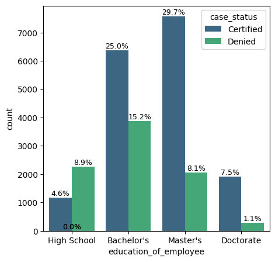

```python
# create a plot of the data above, but additionally with  the percent of each group within the total number of cases

labeled_barplot(df,'education_of_employee','case_status', order=["High School","Bachelor's","Master's","Doctorate"], perc=True)
```

- As the graph above shows, the ratio of applicationbeing certified versus denied increases considerably as an appicant's highest level of education achieved increases.
- The ratio of an applicant with a high school diploma being approved versus denied is 1:2 whereas the same ratio for an applicant with the docrate is 7:1 .
2. **How does the visa status vary cross different continents?**

```python
# group data by continent and count the numbers of each case_status for each category

df.groupby ('continent')['case_status'].value_counts()
```

| continent | case_status | count |
| --- | --- | --- |
| Africa | Certified | 397 |
|  | Denied | 154 |
| Asia | Certified | 11012 |
|  | Denied | 5849 |
| Europe | Certified | 2957 |
|  | Denied | 775 |
| North America | Certified | 2037 |
|  | Denied | 1255 |
| Oceania | Certified | 122 |
|  | Denied | 70 |
| South America | Certified | 493 |
|  | Denied | 359 |

**dtype:** int64

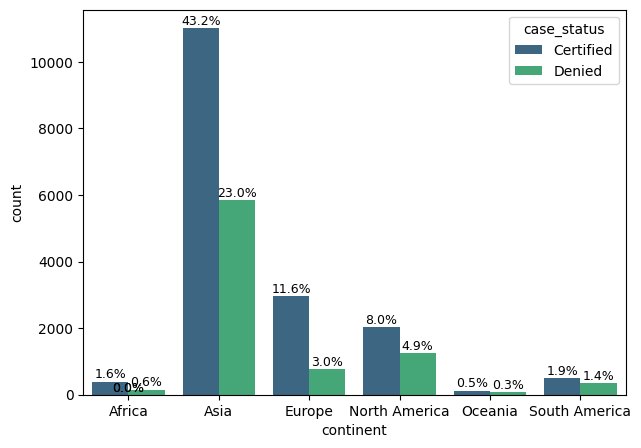

```python
# create a plot of the data above, but additipnally with the percent of each group within the total number of cases
labeled_barplot(df,'continent','case_status', order=None, perc=True)
```

- Application from Asia comprise 2/3 of all applications and these applicants have almost a 2:1 ratio of approvals to denials.
- An application from a European applicant has the best ratio of approvals to denials (4:1)

# 3 . Experienced professionals might look abroad for opportunites to improve their lifestyles and career development . Does work experience influence visa status?

```python
# group data by has_job_experience and count the numbers of each case_status for each category
df.groupby('has_job_experience')['case_status'].value_counts()
```

| has_job_experience | case_status | count |
| --- | --- | --- |
| N | Certified | 5994 |
|  | Denied | 4684 |
| Y | Certified | 11024 |
|  | Denied | 3778 |

**dtype:** int64

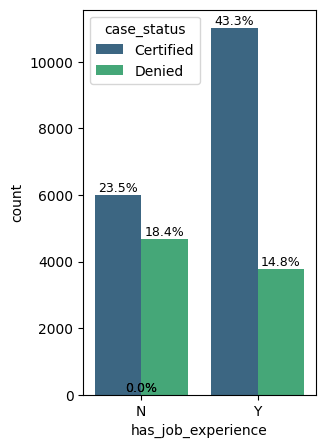

```python
# create a plot of the data above, but additionally with the percent of each group within the total number of cases
labeled_barplot(df,'has_job_experience', 'case_status', order=None, perc=True)
```

- Applicants with job experience have a ratio of approved to denied application of 3:1 whereas the same ratio of applicants without job experience have around a 5:4 ratio (i.e approximately equivalent)

4 .*** In the united states, employee are paid at different intervals . which pay unit is most likely to be certified for a visa?***

```python
# group data by unit_of_wage and count the numbers of each case_status for each category
df.groupby('unit_of_wage')['case_status'].value_counts()
```

| unit_of_wage | case_status | count |
| --- | --- | --- |
| Hour | Denied | 1410 |
|  | Certified | 747 |
| Month | Certified | 55 |
|  | Denied | 34 |
| Week | Certified | 169 |
|  | Denied | 103 |
| Year | Certified | 16047 |
|  | Denied | 6915 |

**dtype:** int64

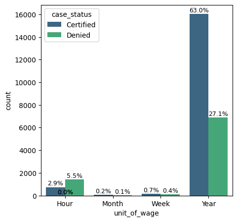

```python
# create a plot of the data above, but additionally with the percent of each group with the total number of cases
labeled_barplot(df,'unit_of_wage','case_status', order=None, perc=True)
```

- Applicants who are applying to work in ajob with an hourly rate have a ratio of approved versus denied applications (1:2) additionally, these applicants comprise only 8% of all applications, but comprise 17% of all denials
- Applicants from any other unit_of_wage category have a ratio of 2:1, with applications for jobs with annual salaries showing nearly a 2.5:1 ratio of approvals to danials

**5. The US government has established a prevailing wage to protect local talent and foreign workers. How does the visa status change with the prevailing wage?**

```python
#group data by unit_of_wage and calculate the mean prevailing_wage for each category
df.groupby('unit_of_wage')['prevailing_wage'].mean()
```

| unit_of_wage | prevailing_wage |
| --- | --- |
| Hour | 414.570513 |
| Month | 87592.864045 |
| Week | 85606.820515 |
| Year | 81228.077133 |

**dtype:** float64

The data shows that the unit_of_wage 'Hour' is a per-day amount, whearas the other three unit_of_wage categories are an annual salary amount.

## Data Preprocessing

- Missing value treatment (if needed)
- Feature engineering
- Outlier detection and treatment (if needed)
- Preparing data for modeling
- Any other preprocessing steps (if needed)

# Data Preprocessing

- Feature engineering
- outlier detedtion and treatment

```python
# Show the number of rows with a value of no_of_employees less than 0 which is not a possible value
df[df.no_of_employees<0].shape
```

```
(33, 11)
```

```python
# drop the rows with error shown above and check the remaining number of rows
df = df[df.no_of_employees>0]
df.shape
```

```
(25447, 11)
```

```python
# create bins to categorize companies by the size of their overall workface
bins = [0,1000,2000,3000,4000,np.Inf]
names = ['0-1000','1000-2000','2000-3000','3000-4000','4000+']
# assign each applicants to a category which indicates the size of a company he or she is applying to
df['company_size'] = pd.cut(df['no_of_employees'], bins, labels=names)
df.company_size.value_counts()
```

| company_size | count |
| --- | --- |
| 0-1000 | 6208 |
| 1000-2000 | 5915 |
| 2000-3000 | 4978 |
| 4000+ | 4798 |
| 3000-4000 | 3548 |

**dtype:** int64

```python
# create the bins to categorize companies by the number of years since the company waas founded
bins =[0,1966,1986,1996,2006,np.Inf]
names = ['50+','30-50','20-30','10-20','0-10']
# assign each applicants to a category which indicates how long the company has been in business(i.e; a proxy for how well- established the company is)
df['company_age'] = pd.cut(df['yr_of_estab'], bins, labels=names)
df.company_age.value_counts()
```

| company_age | count |
| --- | --- |
| 10-20 | 8367 |
| 50+ | 5106 |
| 0-10 | 4849 |
| 30-50 | 3739 |
| 20-30 | 3386 |

**dtype:** int64

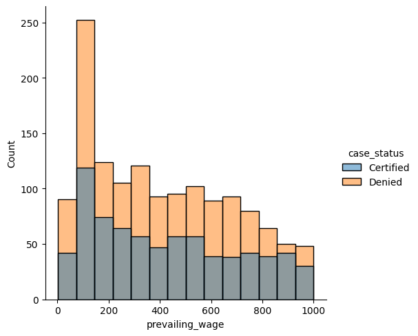

```python
# create a datafarme only of workers applying for job with a *unit_wage* of hour
df_hourly = df[df.unit_of_wage=='Hour']
# show a distribution of the *prevailing_wage* within this dataframe, along withthe ratio of *case_status*  within each bin
sns.displot(data=df_hourly, x='prevailing_wage', hue='case_status')
plt.show()
```

```python
# create bins that categorize applicants by the per_day wage of the job he or she is applying for
bins = list (np.arange(0,1100,200))
#assigns each applicants to a category
df_hourly['income_per_day'] = pd.cut(df_hourly['prevailing_wage'], bins)
df_hourly.groupby('income_per_day')['case_status'].value_counts()
```

| income_per_day | case_status | count |
| --- | --- | --- |
| (0, 200] | Denied | 446 |
|  | Certified | 219 |
| (200, 400] | Denied | 300 |
|  | Certified | 166 |
| (400, 600] | Denied | 274 |
|  | Certified | 144 |
| (600, 800] | Denied | 238 |
|  | Certified | 116 |
| (800, 1000] | Denied | 148 |
|  | Certified | 102 |

**dtype:** int64

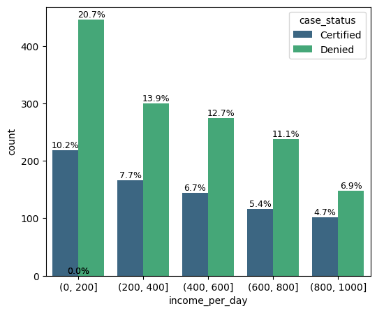

```python
# create a plot of the data above, but additionally with the percentage of each group within the total number of cases
labeled_barplot(df_hourly,'income_per_day','case_status',perc=True, order=None)
```

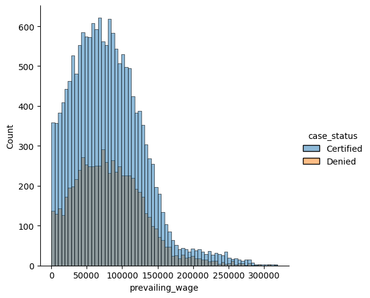

```python
# create a new datframe of only those applicants applying for job with annual salaries (i.e, not, hour)
df_annual = df[df.unit_of_wage !='Hour']
# show the distribution of annual salaries, along with ratio of 'case_status' within each bin
plt.figure(figsize=(16,6))
sns.displot(data=df_annual, x='prevailing_wage', hue='case_status')
plt.show()
```

- The distribution of wages is (as expected) right skewed, indicating a long-tail of jobs with annual salaries above 150,000 dollars
- As the distribution above shows, the ratio of approved to denied application remains approximately equivalent across the range of wages.

```python
# create bins to categorize a job by its annual salary, which indicates how well paying the job is
bins = [0,25000,50000,75000,100000,125000,np.inf]
names = ['$0-25000','$25000-50000','$50000-75000','$75000-100000','$100000-125000','$125k+']
#assign an applicant to a category
df_annual['income_per_year'] = pd.cut(df_annual['prevailing_wage'], bins, labels=names)
df_annual.groupby('income_per_year')['case_status'].value_counts()
```

| income_per_year | case_status | count |
| --- | --- | --- |
| $0-25000 | Certified | 2089 |
|  | Denied | 759 |
| $25000-50000 | Certified | 2835 |
|  | Denied | 1232 |
| $50000-75000 | Certified | 3132 |
|  | Denied | 1371 |
| $75000-100000 | Certified | 3011 |
|  | Denied | 1315 |
| $100000-125000 | Certified | 2405 |
|  | Denied | 1138 |
| $125k+ | Certified | 2782 |
|  | Denied | 1225 |

**dtype:** int64

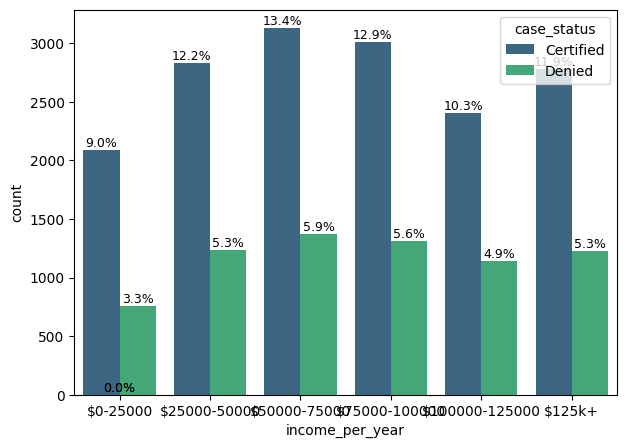

```python
# create a plot of the data above, but additionally with the percent of each group within the total number of cases
labeled_barplot(df_annual,'income_per_year','case_status',perc=True, order=None)
```

OBSERVATION:

- There does not appear to be a significant change in ratio of approved to denied application as income_per_year increase. to the contary, the ratio may actually decrease as this prevailing_wage increase.
- for applications for job with an income_per_year wage, the highest concentration of applications is for jobs with 50,000 to 75,000per year in a salary .

# Summary of a int64 variable

```python
# provide summary of a statistics of all float 64 variable
df.describe(include = ['int64']).T
```

|  | count | mean | std | min | 25% | 50% | 75% | max |
| --- | --- | --- | --- | --- | --- | --- | --- | --- |
| no_of_employees | 25447.0 | 5674.415334 | 22891.842245 | 12.0 | 1025.0 | 2112.0 | 3506.5 | 602069.0 |
| yr_of_estab | 25447.0 | 1979.394506 | 42.385932 | 1800.0 | 1976.0 | 1997.0 | 2005.0 | 2016.0 |

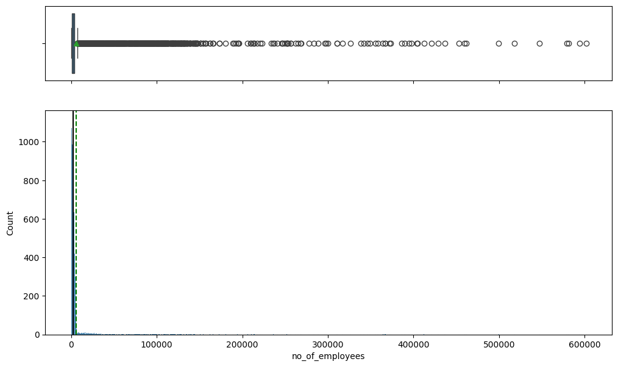

```python
# provide histogram and boxplots
histogram_boxplot(df, 'no_of_employees')
```

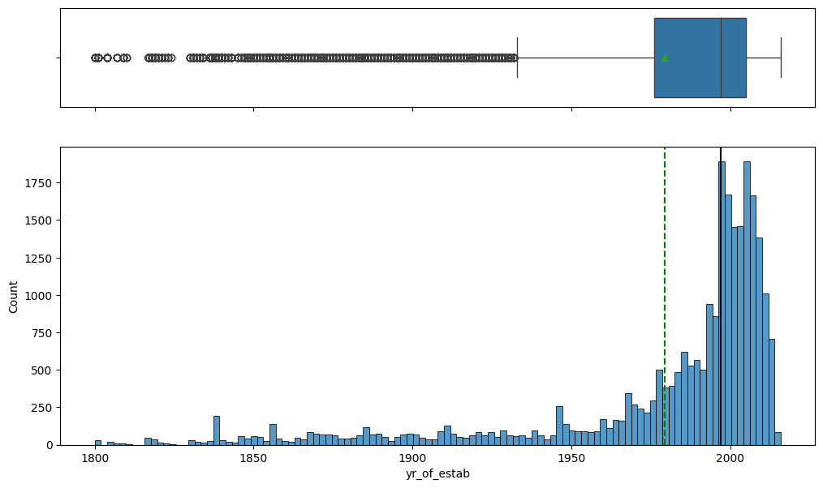

```python
histogram_boxplot(df, 'yr_of_estab')
```

- The data and graphs above, indicates the distribution of companies by year of eatablishment is heavily left skewed ,but without any outlier values which required further investigation or treatment

# Summary of float64 variable

```python
# provide summary statistics of all float64 variable
df_annual.describe(include=['float64']).T
```

|  | count | mean | std | min | 25% | 50% | 75% | max |
| --- | --- | --- | --- | --- | --- | --- | --- | --- |
| prevailing_wage | 23294.0 | 81312.84239 | 49943.366126 | 100.0 | 43860.9325 | 76257.68 | 111414.4475 | 319210.27 |

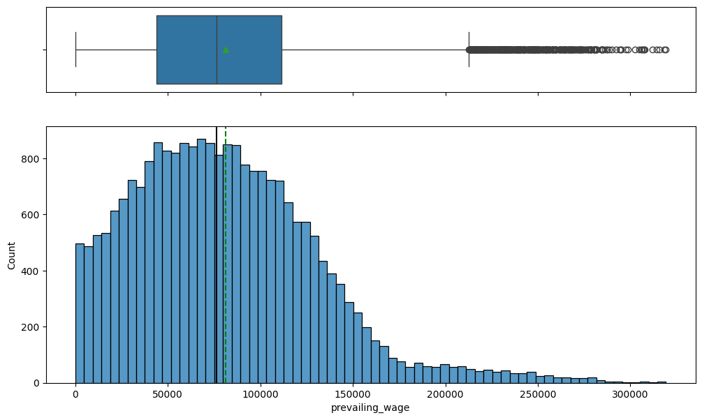

```python
# provide histogram and bloxplot
histogram_boxplot(df_annual, 'prevailing_wage')
```

```python
# provide summary stastitcs of all float64 variable
df_hourly.describe(include=['float64']).T
```

|  | count | mean | std | min | 25% | 50% | 75% | max |
| --- | --- | --- | --- | --- | --- | --- | --- | --- |
| prevailing_wage | 2153.0 | 414.773882 | 275.052214 | 2.1367 | 152.7003 | 373.2045 | 637.3111 | 999.9195 |

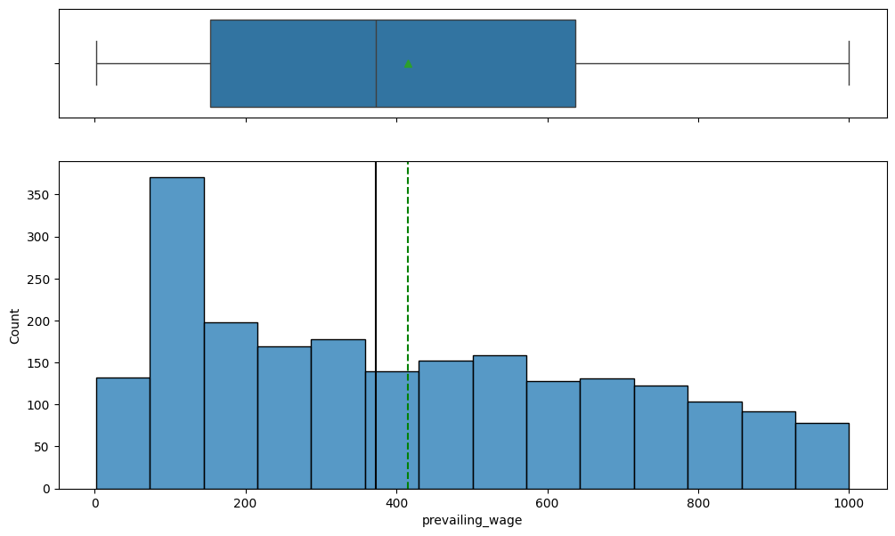

```python
# provide histogram and bloxplot
histogram_boxplot(df_hourly, 'prevailing_wage')
```

# BIVARIATE ANALYSIS

```
continent    Africa   Asia  Europe  North America  Oceania  South America  \
case_status
All             550  16840    3727           3287      192            851
Certified       396  11001    2953           2037      122            492
Denied          154   5839     774           1250       70            359

continent      All
case_status
All          25447
Certified    17001
Denied        8446
------------------------------------------------------------------------------------------------------------------------
```

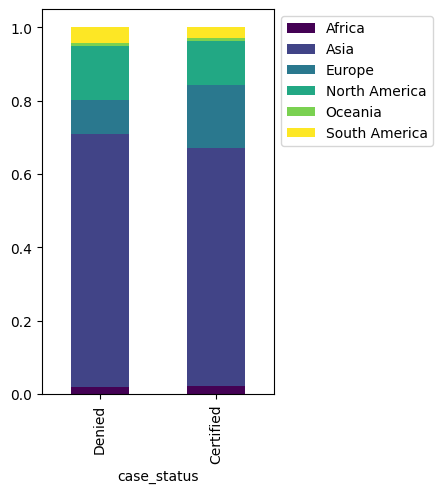

```
education_of_employee  Bachelor's  Doctorate  High School  Master's    All
case_status
All                         10220       2189         3416      9622  25447
Certified                    6362       1910         1164      7565  17001
Denied                       3858        279         2252      2057   8446
------------------------------------------------------------------------------------------------------------------------
```

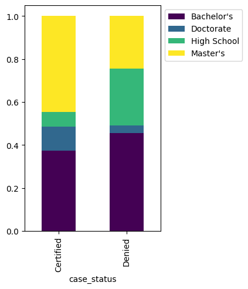

```
has_job_experience      N      Y    All
case_status
All                 10661  14786  25447
Certified            5986  11015  17001
Denied               4675   3771   8446
------------------------------------------------------------------------------------------------------------------------
```

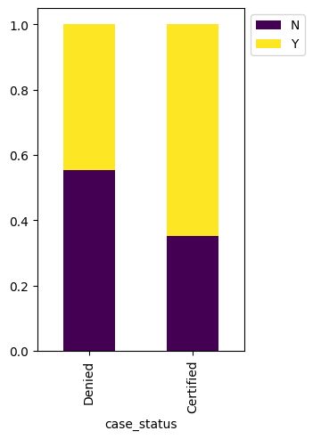

```
requires_job_training      N     Y    All
case_status
All                    22498  2949  25447
Certified              15000  2001  17001
Denied                  7498   948   8446
------------------------------------------------------------------------------------------------------------------------
```

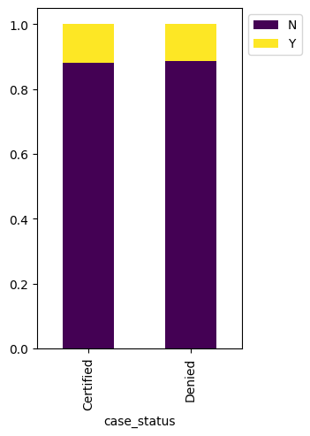

```
region_of_employment  Island  Midwest  Northeast  South  West    All
case_status
All                      375     4299       7189   7006  6578  25447
Certified                226     3246       4524   4908  4097  17001
Denied                   149     1053       2665   2098  2481   8446
------------------------------------------------------------------------------------------------------------------------
```

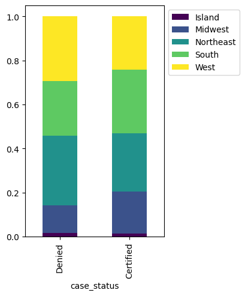

```
unit_of_wage  Hour  Month  Week   Year    All
case_status
All           2153     89   272  22933  25447
Certified      747     55   169  16030  17001
Denied        1406     34   103   6903   8446
------------------------------------------------------------------------------------------------------------------------
```

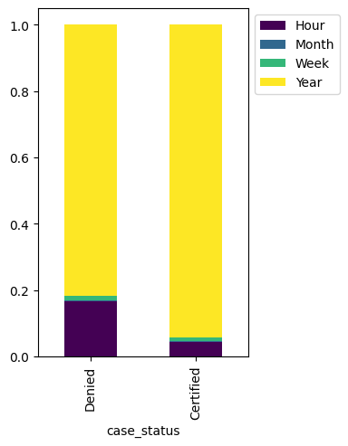

```
full_time_position     N      Y    All
case_status
All                 2706  22741  25447
Certified           1855  15146  17001
Denied               851   7595   8446
------------------------------------------------------------------------------------------------------------------------
```

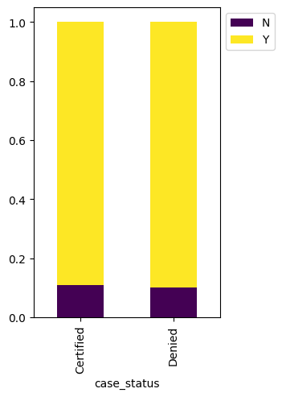

```
case_status  Certified  Denied    All
case_status
Denied               0    8446   8446
All              17001    8446  25447
Certified        17001       0  17001
------------------------------------------------------------------------------------------------------------------------
```

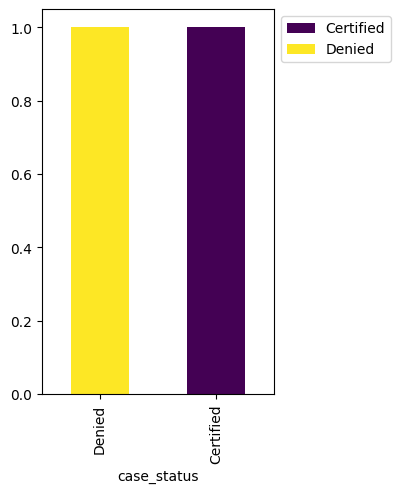

```
company_size  0-1000  1000-2000  2000-3000  3000-4000  4000+    All
case_status
All             6208       5915       4978       3548   4798  25447
Certified       4091       3878       3330       2341   3361  17001
Denied          2117       2037       1648       1207   1437   8446
------------------------------------------------------------------------------------------------------------------------
```

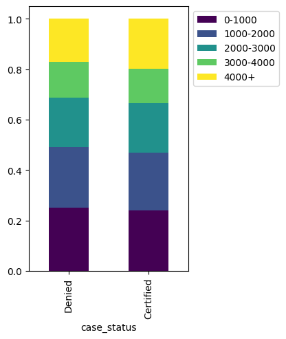

```
company_age   50+  30-50  20-30  10-20  0-10    All
case_status
All          5106   3739   3386   8367  4849  25447
Certified    3385   2466   2226   5567  3357  17001
Denied       1721   1273   1160   2800  1492   8446
------------------------------------------------------------------------------------------------------------------------
```

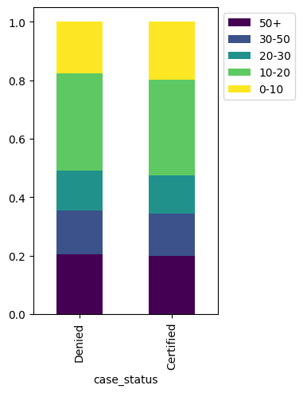

```python
# Create a table and stacked barplot for each variable with a data type of category by case_status
cols_cat = df.select_dtypes(['category'])
for i in cols_cat.columns:
  stacked_barplot(df, "case_status", i)
```

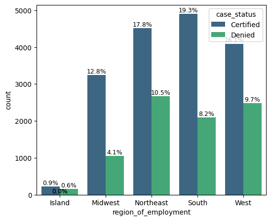

```python
# create a barplot of region of employment for an applicant's job with the corresponding percent of approved and denied cases fro each
labeled_barplot(df, 'region_of_employment', 'case_status',perc=True,order=None)
```

```python
#create tables listing the mean wage for each unique value within each variable with a data type category
for col in df.dtypes[df.dtypes =='category'].index:
  print(df.groupby(col)['prevailing_wage'].mean())
  print(" ")
```

```
continent
Africa           77422.787838
Asia             79562.030424
Europe           59829.199870
North America    68099.801608
Oceania          75994.276719
South America    60127.915661
Name: prevailing_wage, dtype: float64

education_of_employee
Bachelor's     73427.276060
Doctorate      64556.271253
High School    71598.598186
Master's       78847.756007
Name: prevailing_wage, dtype: float64

has_job_experience
N    75475.367533
Y    73742.152411
Name: prevailing_wage, dtype: float64

requires_job_training
N    73422.181345
Y    82449.007425
Name: prevailing_wage, dtype: float64

region_of_employment
Island       91712.750760
Midwest      91691.666673
Northeast    67886.113189
South        74064.955159
West         69852.122027
Name: prevailing_wage, dtype: float64

unit_of_wage
Hour       414.773882
Month    87592.864045
Week     85606.820515
Year     81237.541122
Name: prevailing_wage, dtype: float64
```

[output cut: 11 more lines]

```
company_size
0-1000       75699.052322
1000-2000    74402.660088
2000-3000    76191.795276
3000-4000    73749.743295
4000+        71699.887761
Name: prevailing_wage, dtype: float64

company_age
50+      72865.117292
30-50    74652.408337
20-30    73657.991179
10-20    75498.726703
0-10     74802.208844
Name: prevailing_wage, dtype: float64
```

# Data preprocessing

- preparing data for modeling

```python
# drop  the int64 columns from the dataframe, since this information is captured through the features enginnered allowed
df.drop(labels=['no_of_employees','yr_of_estab'], axis=1, inplace=True)
```

# Encoding certified as 1 AND denied as 0, as the oflc wants to identify those visa applicants who are predicated to be approved.

```python
df["case_status"] = df["case_status"].apply(lambda x: 1 if x == "Certified" else 0)
```

## EDA

- It is a good idea to explore the data once again after manipulating it.

```python
df.tail()
```

|  | continent | education_of_employee | has_job_experience | requires_job_training | region_of_employment | prevailing_wage | unit_of_wage | full_time_position | case_status | company_size | company_age |
| --- | --- | --- | --- | --- | --- | --- | --- | --- | --- | --- | --- |
| 25475 | Asia | Bachelor's | Y | Y | South | 77092.57 | Year | Y | 1 | 2000-3000 | 0-10 |
| 25476 | Asia | High School | Y | N | Northeast | 279174.79 | Year | Y | 1 | 3000-4000 | 10-20 |
| 25477 | Asia | Master's | Y | N | South | 146298.85 | Year | N | 1 | 1000-2000 | 50+ |
| 25478 | Asia | Master's | Y | Y | West | 86154.77 | Year | Y | 1 | 1000-2000 | 50+ |
| 25479 | Asia | Bachelor's | Y | N | Midwest | 70876.91 | Year | Y | 1 | 3000-4000 | 50+ |

```python
df.head()
```

|  | continent | education_of_employee | has_job_experience | requires_job_training | region_of_employment | prevailing_wage | unit_of_wage | full_time_position | case_status | company_size | company_age |
| --- | --- | --- | --- | --- | --- | --- | --- | --- | --- | --- | --- |
| 0 | Asia | High School | N | N | West | 592.2029 | Hour | Y | 0 | 4000+ | 0-10 |
| 1 | Asia | Master's | Y | N | Northeast | 83425.6500 | Year | Y | 1 | 2000-3000 | 10-20 |
| 2 | Asia | Bachelor's | N | Y | West | 122996.8600 | Year | Y | 0 | 4000+ | 0-10 |
| 3 | Asia | Bachelor's | N | N | West | 83434.0300 | Year | Y | 0 | 0-1000 | 50+ |
| 4 | Africa | Master's | Y | N | South | 149907.3900 | Year | Y | 1 | 1000-2000 | 10-20 |

```python
df.info()
```

```
<class 'pandas.core.frame.DataFrame'>
Index: 25447 entries, 0 to 25479
Data columns (total 11 columns):
 #   Column                 Non-Null Count  Dtype
---  ------                 --------------  -----
 0   continent              25447 non-null  category
 1   education_of_employee  25447 non-null  category
 2   has_job_experience     25447 non-null  category
 3   requires_job_training  25447 non-null  category
 4   region_of_employment   25447 non-null  category
 5   prevailing_wage        25447 non-null  float64
 6   unit_of_wage           25447 non-null  category
 7   full_time_position     25447 non-null  category
 8   case_status            25447 non-null  category
 9   company_size           25447 non-null  category
 10  company_age            25447 non-null  category
dtypes: category(10), float64(1)
memory usage: 647.8 KB
```

```python
#create a dataframe of the predictor feature columns
X = df.drop('case_status',axis=1)
#create a datafrane of the predicted class (1=True, 0=False)
y = df['case_status']

#generate dummy variables for each categorical variable
X = pd.get_dummies(X, drop_first=True)

#split the data into train and test datasets
X_train, X_test, y_train, y_test = train_test_split(X, y, test_size=0.2, random_state=1)
```

## Building bagging and boosting models

**Note**

1. Sample parameter grids have been provided to do necessary hyperparameter tuning. These sample grids are expected to provide a balance between model performance improvement and execution time. One can extend/reduce the parameter grid based on execution time and system configuration.
- Please note that if the parameter grid is extended to improve the model performance further, the execution time will increase
- For Gradient Boosting:

```
param_grid = {
    "init": [AdaBoostClassifier(random_state=1),DecisionTreeClassifier(random_state=1)],
    "n_estimators": np.arange(50,110,25),
    "learning_rate": [0.01,0.1,0.05],
    "subsample":[0.7,0.9],
    "max_features":[0.5,0.7,1],
}
```

- For Adaboost:

```
param_grid = {
    "n_estimators": np.arange(50,110,25),
    "learning_rate": [0.01,0.1,0.05],
    "base_estimator": [
        DecisionTreeClassifier(max_depth=2, random_state=1),
        DecisionTreeClassifier(max_depth=3, random_state=1),
    ],
}
```

- For Bagging Classifier:

```
param_grid = {
    'max_samples': [0.8,0.9,1],
    'max_features': [0.7,0.8,0.9],
    'n_estimators' : [30,50,70],
}
```

- For Random Forest:

```
param_grid = {
    "n_estimators": [50,110,25],
    "min_samples_leaf": np.arange(1, 4),
    "max_features": [np.arange(0.3, 0.6, 0.1),'sqrt'],
    "max_samples": np.arange(0.4, 0.7, 0.1)
}
```

- For Decision Trees:

```
param_grid = {
    'max_depth': np.arange(2,6),
    'min_samples_leaf': [1, 4, 7],
    'max_leaf_nodes' : [10, 15],
    'min_impurity_decrease': [0.0001,0.001]
}
```

- For XGBoost:

```
param_grid={'n_estimators':np.arange(50,110,25),
            'scale_pos_weight':[1,2,5],
            'learning_rate':[0.01,0.1,0.05],
            'gamma':[1,3],
            'subsample':[0.7,0.9]
}
```

```python
"""
    To plot the confusion_matrix with percentages

    model: classifier
    predictors: independent variables
    target: dependent variable
"""
def confusion_matrix_sklea(model, predictors, target):
    y_pred = model.predict(predictors)
    cm = confusion_matrix(target, y_pred)
    labels = np.asarray(
        [
            ["{0:0.0f}".format(item) + "\n{0:.2%}".format(item / cm.flatten().sum())]
            for item in cm.flatten()
        ]
    ).reshape(2, 2)

    plt.figure(figsize=(6, 4))
    sns.heatmap(cm, annot=labels, fmt="")
    plt.ylabel("True label")
    plt.xlabel("Predicted label")
```

```python
# defining a function to compute different metrics to check performance of a classification model built using sklearn
"""
    Function to compute different metrics to check classification model performance

    model: classifier
    predictors: independent variables
    target: dependent variable
"""
def model_performance_classification_sklearn(model, predictors, target):
    # predicting using the independent variables
    pred = model.predict(predictors)

    acc = accuracy_score(target, pred)  # to compute Accuracy
    recall = recall_score(target, pred)  # to compute Recall
    precision = precision_score(target, pred)  # to compute Precision
    f1 = f1_score(target, pred)  # to compute F1-score

    # creating a dataframe of metrics
    df_perf = pd.DataFrame(
        {
            "Accuracy": acc,
            "Recall": recall,
            "Precision": precision,
            "F1": f1,
        },
        index=[0],
    )

    return df_perf
```

**For Gradient Boosting:**

```python
# Choose the type of classifier.
gb_tuned = GradientBoostingClassifier(random_state=1)

param_grid = {
    "init": [AdaBoostClassifier(random_state=1),DecisionTreeClassifier(random_state=1)],
    "n_estimators": np.arange(50,110,25),
    "learning_rate": [0.01,0.1,0.05],
    "subsample":[0.7,0.9],
    "max_features":[0.5,0.7,1],
}

# Type of scoring used to compare parameter combinations
scorer = metrics.make_scorer(metrics.f1_score)

# Run the randomized search
rand_gb = RandomizedSearchCV(gb_tuned, param_grid, scoring=scorer,cv=5, n_jobs=-1, random_state=1)
rand_gb = rand_gb.fit(X_train, y_train)

# Set the clf to the best combination of parameters
gb_tuned = rand_gb.best_estimator_

# Fit the best algorithm to the data.
gb_tuned.fit(X_train, y_train)
```

```
GradientBoostingClassifier(init=AdaBoostClassifier(random_state=1),
                           learning_rate=0.05, max_features=1, n_estimators=50,
                           random_state=1, subsample=0.7)
```

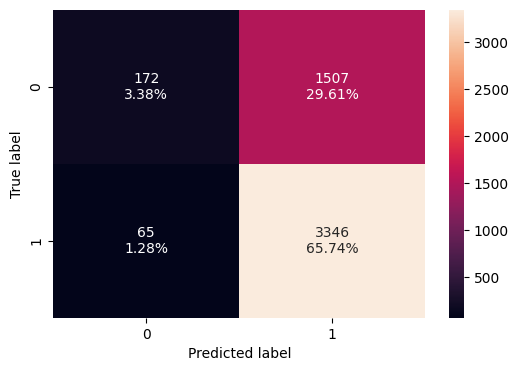

```python
#create a confusion matrix of the classifier's performance on the testing data
confusion_matrix_sklea(gb_tuned, X_test,y_test)
```

```python
gb_tuned_model_train_perf=model_performance_classification_sklearn(gb_tuned, X_train,y_train)
print("Training performance \n",gb_tuned_model_train_perf)
```

```
Training performance
    Accuracy    Recall  Precision       F1
0  0.690279  0.984327   0.687092  0.80928
```

```python
gb_tuned_model_test_perf=model_performance_classification_sklearn(gb_tuned, X_test, y_test)
print("Testing performance \n",gb_tuned_model_test_perf)
```

```
Testing performance
    Accuracy    Recall  Precision        F1
0  0.691159  0.980944    0.68947  0.809777
```

**For Adaboost:**

```python
# Choose the type of classifier.
abc_tuned = AdaBoostClassifier(random_state=1)

# Grid of parameters to choose from
## add from article

param_grid = {
    "n_estimators": np.arange(50,110,25),
    "learning_rate":[0.01,0.1,0.05],
    "estimator": [
        DecisionTreeClassifier(max_depth=2, random_state=1),
        DecisionTreeClassifier(max_depth=3, random_state=1)]
    }

# Type of scoring used to compare parameter combinations
scorer = metrics.make_scorer(metrics.f1_score)

# Run the grid search
grid_obj = GridSearchCV(abc_tuned, param_grid, scoring=scorer,cv=2, n_jobs=-1)
grid_obj = grid_obj.fit(X_train, y_train)

# Set the clf to the best combination of parameters
abc_tuned = grid_obj.best_estimator_

# Fit the best algorithm to the data.
abc_tuned.fit(X_train, y_train)
```

```
AdaBoostClassifier(estimator=DecisionTreeClassifier(max_depth=3,
                                                    random_state=1),
                   learning_rate=0.01, n_estimators=100, random_state=1)
```

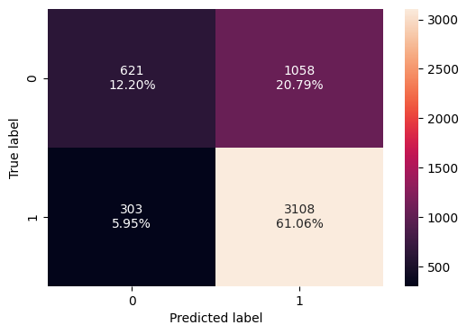

```python
#create a confusion matrix of the classifier's performance on the testing data
confusion_matrix_sklea(abc_tuned, X_test,y_test)
```

```python
abc_tuned_model_train_perf=model_performance_classification_sklearn(abc_tuned, X_train,y_train)
print("Training performance \n",abc_tuned_model_train_perf)
```

```
Training performance
    Accuracy    Recall  Precision        F1
0  0.736553  0.916115   0.746716  0.822787
```

```python
abc_tuned_model_test_perf=model_performance_classification_sklearn(abc_tuned, X_test, y_test)
print("Testing performance \n",abc_tuned_model_test_perf)
```

```
Testing performance
    Accuracy   Recall  Precision        F1
0  0.732613  0.91117   0.746039  0.820377
```

**For Bagging Classifier:**

```python
# Choose the type of classifier.
bagging_estimator_tuned = BaggingClassifier(random_state=1)

# Grid of parameters to choose from
param_grid = {
    'max_samples': [0.8,0.9,1],
    'max_features': [0.7,0.8,0.9],
    'n_estimators' : [30,50,70],
}

# Type of scoring used to compare parameter combinations
scorer = metrics.make_scorer(metrics.f1_score)

# Run the grid search
grid_obj = GridSearchCV(bagging_estimator_tuned, param_grid, scoring=scorer,cv=2)
grid_obj = grid_obj.fit(X_train, y_train)

# Set the clf to the best combination of parameters
bagging_estimator_tuned = grid_obj.best_estimator_

# Fit the best algorithm to the data.
bagging_estimator_tuned.fit(X_train, y_train)
```

```
BaggingClassifier(max_features=0.7, max_samples=0.8, n_estimators=50,
                  random_state=1)
```

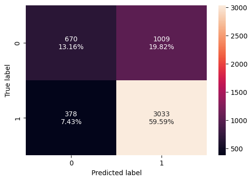

```python
#create a confusion matrix of the classifier's performance on the testing data
confusion_matrix_sklea(bagging_estimator_tuned, X_test,y_test)
```

```python
bagging_tuned_model_train_perf=model_performance_classification_sklearn(bagging_estimator_tuned, X_train,y_train)
print("Training performance \n",bagging_tuned_model_train_perf)
```

```
Training performance
    Accuracy    Recall  Precision        F1
0  0.976519  0.998234   0.967618  0.982687
```

```python
bagging_tuned_model_test_perf=model_performance_classification_sklearn(bagging_estimator_tuned, X_test, y_test)
print("Testing performance \n",bagging_tuned_model_test_perf)
```

```
Testing performance
    Accuracy    Recall  Precision      F1
0  0.727505  0.889182   0.750371  0.8139
```

**For Random Forest:**

```python
# Choose the type of classifier.
rf_estimator = RandomForestClassifier(random_state=1)

# Grid of parameters to choose from
param_grid = {
    "n_estimators": [50,110,25],
    "min_samples_leaf": np.arange(1, 4),
    "max_features": [np.arange(0.3, 0.6, 0.1),'sqrt'],
    "max_samples": np.arange(0.4, 0.7, 0.1)
}

# Type of scoring used to compare parameter combinations
scorer = metrics.make_scorer(metrics.f1_score)

# Run the randomized search
rand_rf = RandomizedSearchCV(rf_estimator, param_grid, scoring=scorer, cv=2, n_jobs=-1, random_state=1)
rand_rf = rand_rf.fit(X_train, y_train)

# Set the clf to the best combination of parameters
rf_estimator = rand_rf.best_estimator_

# Fit the best algorithm to the data.
rf_estimator.fit(X_train, y_train)
```

```
RandomForestClassifier(max_samples=0.4, min_samples_leaf=3, n_estimators=110,
                       random_state=1)
```

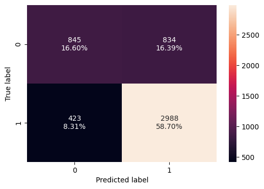

```python
#create a confusion matrix of the classifier's performance on the testing data
confusion_matrix_sklea(rf_estimator, X_test,y_test)
```

```python
rf_tuned_model_train_perf=model_performance_classification_sklearn(rf_estimator, X_train,y_train)
print("Training performance \n",rf_tuned_model_train_perf)
```

```
Training performance
    Accuracy    Recall  Precision       F1
0  0.782483  0.900074   0.799373  0.84674
```

```python
rf_tuned_model_test_perf=model_performance_classification_sklearn(rf_estimator, X_test, y_test)
print("Testing performance \n",rf_tuned_model_test_perf)
```

```
Testing performance
    Accuracy    Recall  Precision        F1
0  0.753045  0.875989    0.78179  0.826213
```

**For Decision Trees:**

```python
# Choose the type of classifier.
dtree_estimator = DecisionTreeClassifier(random_state=1)

# Grid of parameters to choose from
param_grid = {'max_depth': np.arange(2,6),
              'min_samples_leaf': [1, 4, 7],
              'max_leaf_nodes' : [10, 15],
              'min_impurity_decrease': [0.0001,0.001]
              }

# Type of scoring used to compare parameter combinations
scorer = metrics.make_scorer(metrics.f1_score)

# Run the grid search
grid_obj = GridSearchCV(dtree_estimator, param_grid, scoring=scorer, cv=5)
grid_obj = grid_obj.fit(X_train, y_train)

# Set the clf to the best combination of parameters
dtree_estimator = grid_obj.best_estimator_

# Fit the best algorithm to the data.
dtree_estimator.fit(X_train, y_train)
```

```
DecisionTreeClassifier(max_depth=5, max_leaf_nodes=15,
                       min_impurity_decrease=0.0001, random_state=1)
```

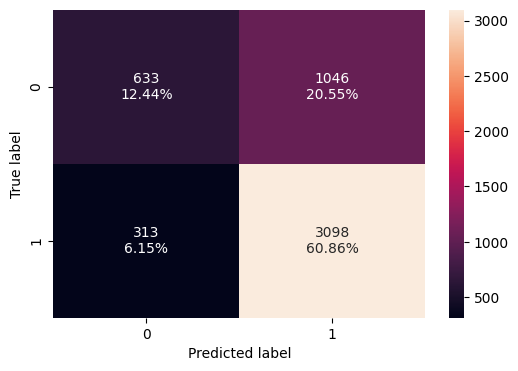

```python
#create a confusion matrix of the classifier's performance on the testing data
confusion_matrix_sklea(dtree_estimator, X_test,y_test)
```

```python
dtree_estimator_model_train_perf=model_performance_classification_sklearn(dtree_estimator, X_train,y_train)
print("Training performance \n",dtree_estimator_model_train_perf)
```

```
Training performance
    Accuracy    Recall  Precision        F1
0   0.73611  0.912362   0.747829  0.821942
```

```python
dtree_estimator_model_test_perf=model_performance_classification_sklearn(dtree_estimator, X_test, y_test)
print("Testing performance \n",dtree_estimator_model_test_perf)
```

```
Testing performance
    Accuracy    Recall  Precision        F1
0  0.733006  0.908238   0.747587  0.820119
```

**For XGBoost:**

```python
# Choose the type of classifier.
xgb_tuned = XGBClassifier(random_state=1, eval_metric='logloss')

# Grid of parameters to choose from
param_grid = {'n_estimators':np.arange(50,110,25),
              'scale_pos_weight':[1,2,5],
              'learning_rate':[0.01,0.1,0.05],
              'gamma':[1,3],
              'subsample':[0.7,0.9]
              }

# Type of scoring used to compare parameter combinations
scorer = metrics.make_scorer(metrics.f1_score)

# Run the randomized search
rand_xgb = RandomizedSearchCV(xgb_tuned, param_grid, scoring=scorer,cv=2, random_state=1)
rand_xgb = rand_xgb.fit(X_train, y_train)

# Set the clf to the best combination of parameters
xgb_tuned = rand_xgb.best_estimator_

# Fit the best algorithm to the data.
xgb_tuned.fit(X_train, y_train)
```

```
XGBClassifier(base_score=None, booster=None, callbacks=None,
              colsample_bylevel=None, colsample_bynode=None,
              colsample_bytree=None, device=None, early_stopping_rounds=None,
              enable_categorical=False, eval_metric='logloss',
              feature_types=None, gamma=3, grow_policy=None,
              importance_type=None, interaction_constraints=None,
              learning_rate=0.05, max_bin=None, max_cat_threshold=None,
              max_cat_to_onehot=None, max_delta_step=None, max_depth=None,
              max_leaves=None, min_child_weight=None, missing=nan,
              monotone_constraints=None, multi_strategy=None, n_estimators=50,
              n_jobs=None, num_parallel_tree=None, random_state=1, ...)
```

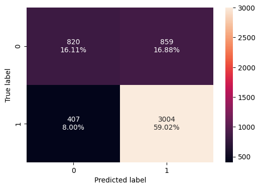

```python
#create a confusion matrix of the classifier's performance on the testing data
confusion_matrix_sklea(xgb_tuned, X_test,y_test)
```

```python
xgb_tuned_model_train_perf=model_performance_classification_sklearn(xgb_tuned, X_train,y_train)
print("Training performance \n",xgb_tuned_model_train_perf)
```

```
Training performance
    Accuracy    Recall  Precision        F1
0  0.754237  0.885504    0.77734  0.827904
```

```python
xgb_tuned_model_test_perf=model_performance_classification_sklearn(xgb_tuned, X_test, y_test)
print("Testing performance \n",xgb_tuned_model_test_perf)
```

```
Testing performance
    Accuracy   Recall  Precision        F1
0  0.751277  0.88068   0.777634  0.825955
```

## Model Performance Comparison and Conclusions

```python
# create a dataframe comparing the performance of the tuned models on the training data

tuned_models_train_comp_df = pd.concat(
    [gb_tuned_model_train_perf.T,
     abc_tuned_model_train_perf.T,
     bagging_tuned_model_train_perf.T,
     rf_tuned_model_train_perf.T,
     dtree_estimator_model_train_perf.T,
     xgb_tuned_model_train_perf.T],
    axis=1,
)
tuned_models_train_comp_df.columns = [
    "Gradient Boosting Classifier",
    "AdaBoost Classifier",
    "Bagging Classifier",
    "Random Forest",
    "Decision Tree",
    "Tuned XGBoost Classifier"]
print("Training performance comparison of models:")
tuned_models_train_comp_df
```

```
Training performance comparison of models:
```

|  | Gradient Boosting Classifier | AdaBoost Classifier | Bagging Classifier | Random Forest | Decision Tree | Tuned XGBoost Classifier |
| --- | --- | --- | --- | --- | --- | --- |
| Accuracy | 0.690279 | 0.736553 | 0.976519 | 0.782483 | 0.736110 | 0.754237 |
| Recall | 0.984327 | 0.916115 | 0.998234 | 0.900074 | 0.912362 | 0.885504 |
| Precision | 0.687092 | 0.746716 | 0.967618 | 0.799373 | 0.747829 | 0.777340 |
| F1 | 0.809280 | 0.822787 | 0.982687 | 0.846740 | 0.821942 | 0.827904 |

```python
# create a dataframe comparing the performance of the tuned models on the testing data

tuned_models_test_comp_df = pd.concat(
    [gb_tuned_model_test_perf.T,
     abc_tuned_model_test_perf.T,
     bagging_tuned_model_test_perf.T,
     rf_tuned_model_test_perf.T,
     dtree_estimator_model_test_perf.T,
     xgb_tuned_model_test_perf.T],
    axis=1,
)
tuned_models_test_comp_df.columns = [
    "Gradient Boosting Classifier",
    "AdaBoost Classifier",
    "Bagging Classifier",
    "Random Forest",
    "Decision Tree",
    "XGBoost Classifier"]
print("Testing performance comparison of models:")
tuned_models_test_comp_df
```

```
Testing performance comparison of models:
```

|  | Gradient Boosting Classifier | AdaBoost Classifier | Bagging Classifier | Random Forest | Decision Tree | XGBoost Classifier |
| --- | --- | --- | --- | --- | --- | --- |
| Accuracy | 0.691159 | 0.732613 | 0.727505 | 0.753045 | 0.733006 | 0.751277 |
| Recall | 0.980944 | 0.911170 | 0.889182 | 0.875989 | 0.908238 | 0.880680 |
| Precision | 0.689470 | 0.746039 | 0.750371 | 0.781790 | 0.747587 | 0.777634 |
| F1 | 0.809777 | 0.820377 | 0.813900 | 0.826213 | 0.820119 | 0.825955 |

```python
# create a dataframe comparing the performance all models on the training data
all_models_train_comp = pd.concat([tuned_models_train_comp_df],axis=1)
all_models_train_comp.T.sort_values('F1',ascending=False)
```

[output not shown]

```python
' The performing model on the train data is ' + all_models_train_comp.T.sort_values('F1',ascending=False).index[0]
```

[output not shown]

```python
# create a dataframe comparing the performance of all models on the testing data
all_models_test_comp = pd.concat([tuned_models_test_comp_df],axis=1)
all_models_test_comp.T.sort_values('F1',ascending=False)
```

[output not shown]

```python
'The performing model on the test data is ' + all_models_test_comp.T.sort_values('F1',ascending=False).index[0]
```

[output not shown]

**Observations**

The Bagging Classifier model performs the best on the training dataset and Random Forest performs the best on the test dataset with 0.826213.

## Actionable Insights and Recommendations

**Insights**

**Recommendations**